# Senmiao Qiu_PS3b_ANLY512_IV_2016

Senmiao Qiu

12/18/2016

## Data Import & Cleanup

```r
library(dplyr)  # for easier filtering
```

```r
library(ggplot2)
movie <- read.csv("~/Documents/HU/520/movie_data2.csv")  # import the csv
str(movie) # Look at the structure of the data frame
```

```
## 'data.frame':    105 obs. of  13 variables:
##  $ title                 : Factor w/ 45 levels "Alice in Wonderland",..: 1 2 3 3 3 4 6 9 11 12 ...
##  $ year                  : int  1949 2009 1943 1966 1989 2006 2003 2009 2010 1996 ...
##  $ length                : int  76 171 260 105 126 117 100 153 148 153 ...
##  $ budget                : int  NA 237000000 NA 1377800 35000000 120000000 94000000 250000000 160000000 75000000 ...
##  $ rating                : num  6.7 8.3 6.8 6.3 7.2 6.9 6.7 7.4 9.1 6.5 ...
##  $ votes                 : int  242 258587 517 9864 79 597 113 167 177798 148993 ...
##  $ mpaa                  : Factor w/ 3 levels "PG","PG-13","R": NA 2 NA NA NA NA NA 1 2 2 ...
##  $ genre                 : Factor w/ 7 levels "Action","Animation",..: 1 1 1 1 1 1 1 1 1 1 ...
##  $ domestic_earnings     : int  334191110 760507625 248972777 248972777 248972777 244082982 380529370 301959197 292576195 306124059 ...
##  $ international_earnings: int  691300000 2023411357 160160000 160160000 160160000 217568264 555900000 633124489 540008221 511231623 ...
##  $ worldwide_earnings    : num  1.03e+09 2.78e+09 4.09e+08 4.09e+08 4.09e+08 ...
##  $ IMDb_rating           : num  7.4 7.9 7.6 7.6 7.6 7.2 8.1 7.4 8.8 6.8 ...
##  $ directors             : Factor w/ 35 levels "Alfonso Cuar\xd5_n",..: 10 14 34 34 34 17 5 11 9 30 ...
```

```r
# Clean up some variables
movie$Domestic <- as.numeric(movie$domestic_earnings)   # Convert these columns to numeric
movie$International <- as.numeric(movie$international_earnings)
movie$Worldwide <- as.numeric(movie$worldwide_earnings)
```

### Vis 1 Distribution of Genre

First, look at the general distribution of movie generes.

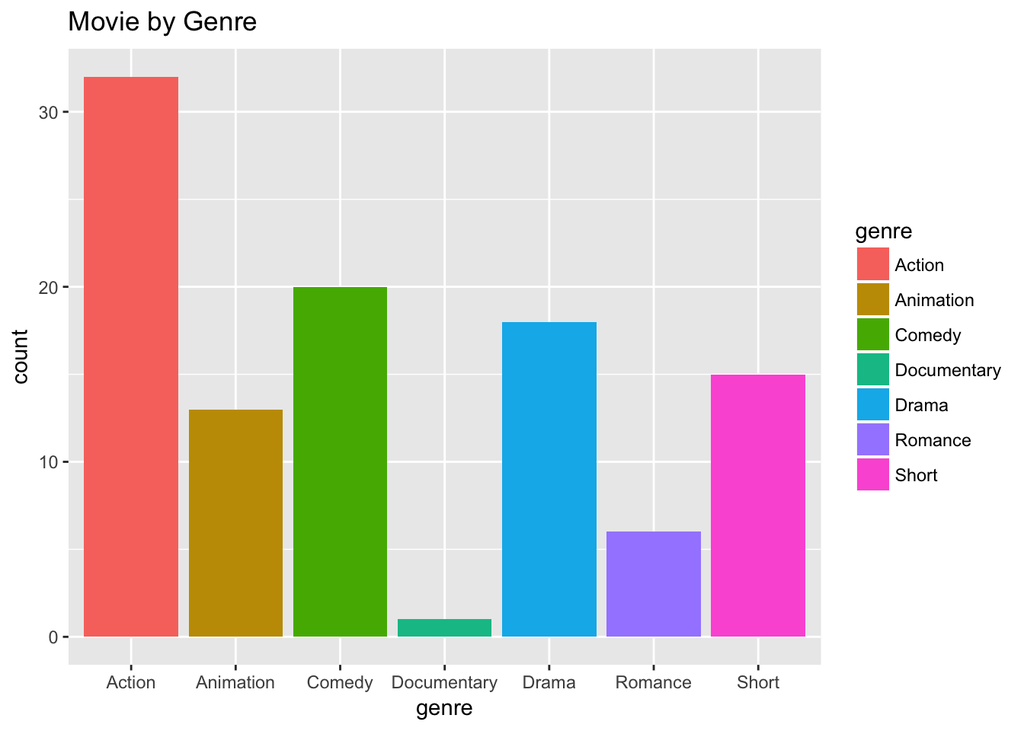

```r
ggplot(movie, aes(genre))+
  geom_bar(aes(fill=genre))+
  labs(title="Movie by Genre")
```

Next, I want to take a look at the change of movie genres throughout the time.

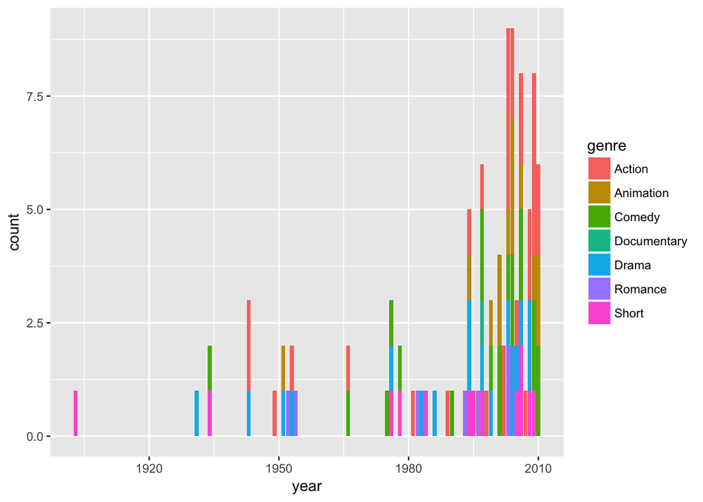

```r
ggplot(movie, aes(year)) +
  geom_bar(aes(fill=genre))
```

By looking at the graph, there is a clear outliker year before 1920. So let’s try get rid of the outlier.

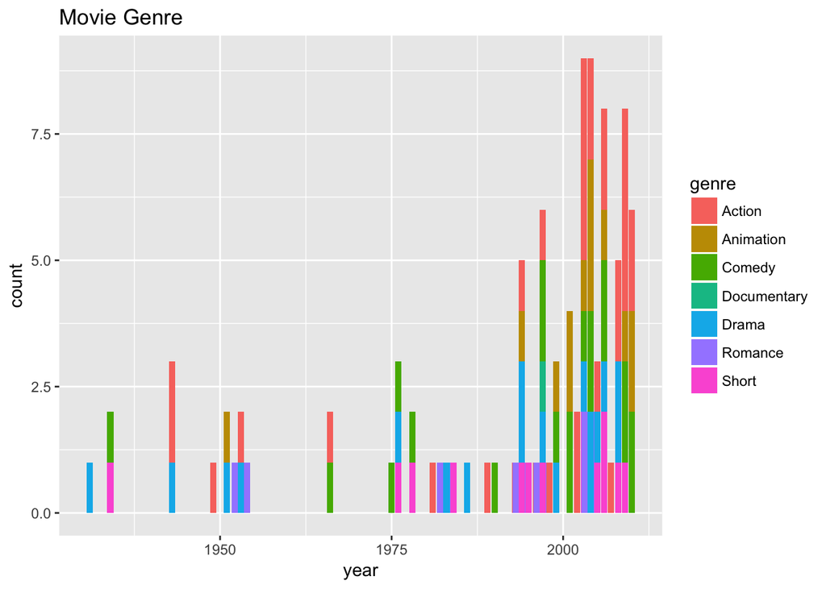

```r
genre<-subset(movie, year>1920)
ggplot(genre, aes(year)) +
  geom_bar(aes(fill=genre))+
  labs(title="Movie Genre")
```

Even in the new graph, data points before 1990 are very limited compared to the time afterwards. So we focus on movie genres after 1990 to see the pattern.

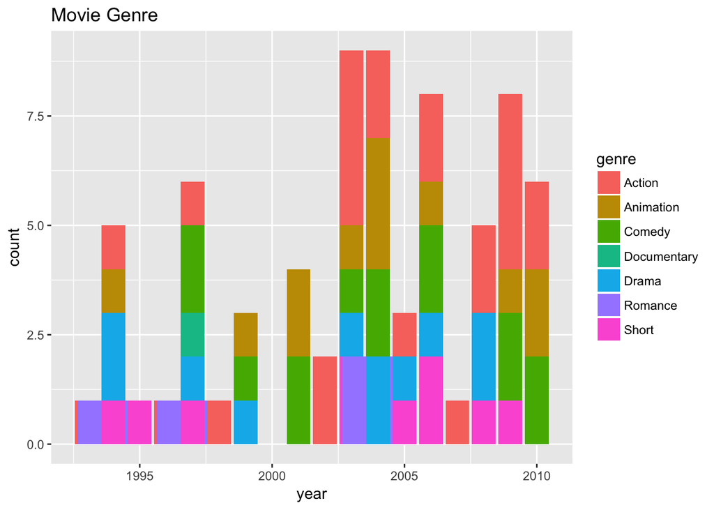

```r
genre<-subset(movie, year>1990)
ggplot(genre, aes(year)) +
  geom_bar(aes(fill=genre))+
  labs(title="Movie Genre")
```

The pattern is not very clear, in some years there were few movies in the data set. But the numbers of action movies and short movies are generally stable.

### Vis 2 Relationships between Movie Ratings and Earnings

The following charts show the relationships between IMDb ratings and rating with worldwide earnings,respectively.

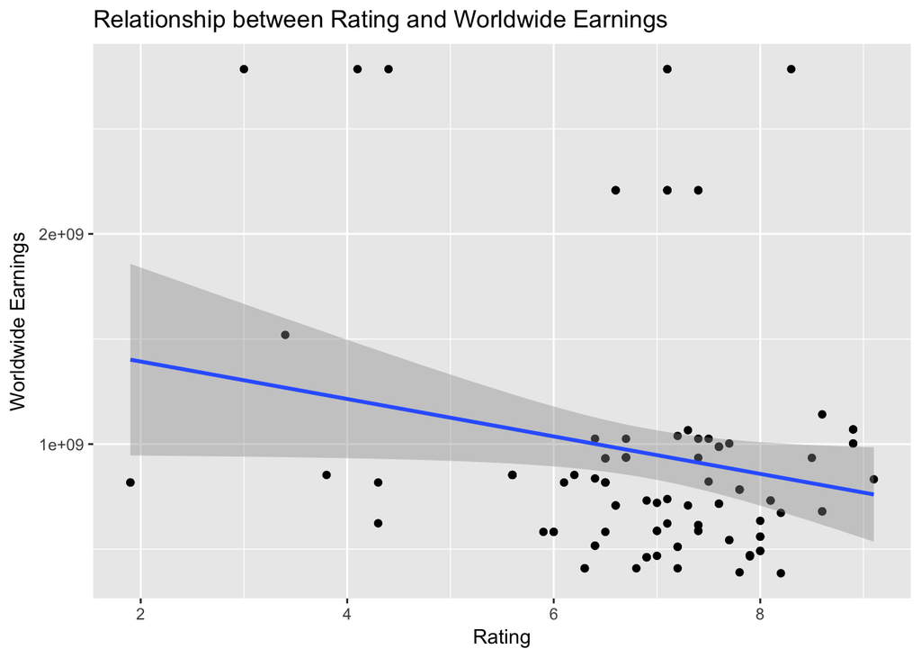

```r
ggplot(movie, aes(rating,Worldwide)) +
  geom_point() + geom_smooth(method="lm") +
  ggtitle("Relationship between Rating and Worldwide Earnings") +
  labs(x="Rating", y="Worldwide Earnings")
```

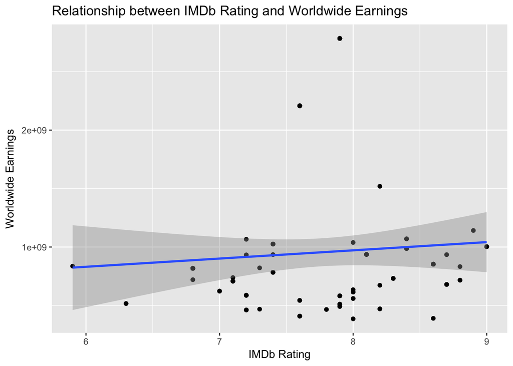

```r
ggplot(movie, aes(IMDb_rating,Worldwide)) +
  geom_point() + geom_smooth(method="lm") +
  ggtitle("Relationship between IMDb Rating and Worldwide Earnings") +
  labs(x="IMDb Rating", y="Worldwide Earnings")
```

### Vis 3 Movie Earnings by Genres

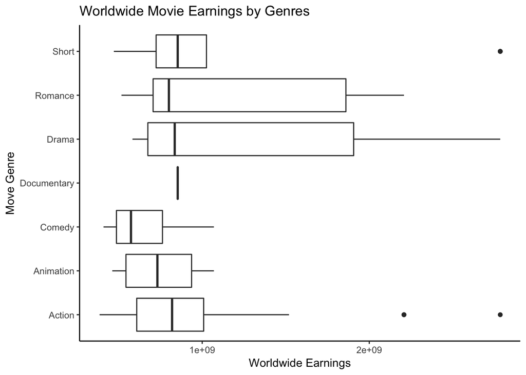

```r
ggplot(movie, aes(genre, Worldwide))+
  geom_boxplot() + labs(title = "Worldwide Movie Earnings by Genres", y = "Worldwide Earnings", x = "Move Genre")+
  coord_flip()+
  theme_classic()
```

Earnings of dramas and romance movies vary the most. And there are two action movies and 1 short movies that had substantially high earnings.

### Vis 4 Domestic Earnings and Internaitonal Earnings

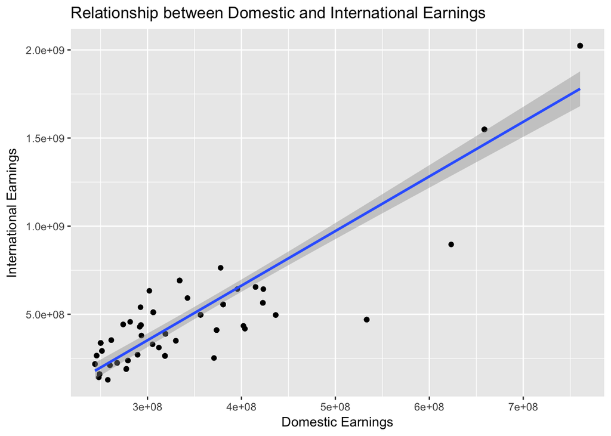

```r
ggplot(movie, aes(Domestic,International)) +
  geom_point() + geom_smooth(method="lm") +
  ggtitle("Relationship between Domestic and International Earnings") +
  labs(x="Domestic Earnings", y="International Earnings")
```

There is a clear positive relationship between movies’ domestic and international earnings. So good movies are generally well received even across different cultures.